# 1. Importing Necessary Libraries

```python
# Библиотеки для работы с данными
import numpy as np
import pandas as pd
import matplotlib.pyplot as plt
import seaborn as sns
import os

import warnings
warnings.filterwarnings("ignore")

# Библиотеки для моделирования
from sklearn.model_selection import train_test_split

from sklearn.preprocessing import StandardScaler
from sklearn.model_selection import GridSearchCV
from sklearn.ensemble import RandomForestClassifier

# Оценка моделей
from sklearn.metrics import accuracy_score
from sklearn.metrics import confusion_matrix
from sklearn.metrics import roc_auc_score, roc_curve
```

# 2. Load Data

# About Dataset

## Context

This dataset is originally from the National Institute of Diabetes and Digestive and Kidney Diseases. The objective of the dataset is to diagnostically predict whether or not a patient has diabetes, based on certain diagnostic measurements included in the dataset. Several constraints were placed on the selection of these instances from a larger database. In particular, all patients here are females at least 21 years old of Pima Indian heritage.

## Content

The datasets consists of several medical predictor variables and one target variable, Outcome. Predictor variables includes the number of pregnancies the patient has had, their BMI, insulin level, age, and so on.

## Acknowledgements

Smith, J.W., Everhart, J.E., Dickson, W.C., Knowler, W.C., & Johannes, R.S. (1988). Using the ADAP learning algorithm to forecast the onset of diabetes mellitus. In Proceedings of the Symposium on Computer Applications and Medical Care (pp. 261--265). IEEE Computer Society Press.

```python
a = os.path.basename("diabetes.csv")
b = os.path.abspath("diabetes.csv").replace(a, '')
df = pd.read_csv(b +"\\" + a, sep=',')
df.head()
```

|  | Pregnancies | Glucose | BloodPressure | SkinThickness | Insulin | BMI | DiabetesPedigreeFunction | Age | Outcome |
| --- | --- | --- | --- | --- | --- | --- | --- | --- | --- |
| 0 | 6 | 148 | 72 | 35 | 0 | 33.6 | 0.627 | 50 | 1 |
| 1 | 1 | 85 | 66 | 29 | 0 | 26.6 | 0.351 | 31 | 0 |
| 2 | 8 | 183 | 64 | 0 | 0 | 23.3 | 0.672 | 32 | 1 |
| 3 | 1 | 89 | 66 | 23 | 94 | 28.1 | 0.167 | 21 | 0 |
| 4 | 0 | 137 | 40 | 35 | 168 | 43.1 | 2.288 | 33 | 1 |

```python
df.info()
```

```
<class 'pandas.core.frame.DataFrame'>
RangeIndex: 768 entries, 0 to 767
Data columns (total 9 columns):
 #   Column                    Non-Null Count  Dtype
---  ------                    --------------  -----
 0   Pregnancies               768 non-null    int64
 1   Glucose                   768 non-null    int64
 2   BloodPressure             768 non-null    int64
 3   SkinThickness             768 non-null    int64
 4   Insulin                   768 non-null    int64
 5   BMI                       768 non-null    float64
 6   DiabetesPedigreeFunction  768 non-null    float64
 7   Age                       768 non-null    int64
 8   Outcome                   768 non-null    int64
dtypes: float64(2), int64(7)
memory usage: 54.1 KB
```

```python
df.describe().T
```

|  | count | mean | std | min | 25% | 50% | 75% | max |
| --- | --- | --- | --- | --- | --- | --- | --- | --- |
| Pregnancies | 768.0 | 3.845052 | 3.369578 | 0.000 | 1.00000 | 3.0000 | 6.00000 | 17.00 |
| Glucose | 768.0 | 120.894531 | 31.972618 | 0.000 | 99.00000 | 117.0000 | 140.25000 | 199.00 |
| BloodPressure | 768.0 | 69.105469 | 19.355807 | 0.000 | 62.00000 | 72.0000 | 80.00000 | 122.00 |
| SkinThickness | 768.0 | 20.536458 | 15.952218 | 0.000 | 0.00000 | 23.0000 | 32.00000 | 99.00 |
| Insulin | 768.0 | 79.799479 | 115.244002 | 0.000 | 0.00000 | 30.5000 | 127.25000 | 846.00 |
| BMI | 768.0 | 31.992578 | 7.884160 | 0.000 | 27.30000 | 32.0000 | 36.60000 | 67.10 |
| DiabetesPedigreeFunction | 768.0 | 0.471876 | 0.331329 | 0.078 | 0.24375 | 0.3725 | 0.62625 | 2.42 |
| Age | 768.0 | 33.240885 | 11.760232 | 21.000 | 24.00000 | 29.0000 | 41.00000 | 81.00 |
| Outcome | 768.0 | 0.348958 | 0.476951 | 0.000 | 0.00000 | 0.0000 | 1.00000 | 1.00 |

# Basic Summary

Данные содержат 9 столбцов и 768 наблюдений. Зависимая переменная - Outcome. Описательный анализ показывает, что переменные BloodPressure, Insulin, BMI имеют минимум из 0, что в реальной жизни невозможно, поэтому вероятно, что данные отсутствуют. Вероятно, количество беременностей (переменная Pregnancies) = 17 окажется выбросом. Также можно заметить, что дисперсия между различными предикторами варьируется в больших масштабах, что означает, что применение масштабирования переменных будет не лишним в разделе препроцессинга данных.

# 3. Missing Values And Outliers

```python
df.isnull().sum()
```

```
Pregnancies                 0
Glucose                     0
BloodPressure               0
SkinThickness               0
Insulin                     0
BMI                         0
DiabetesPedigreeFunction    0
Age                         0
Outcome                     0
dtype: int64
```

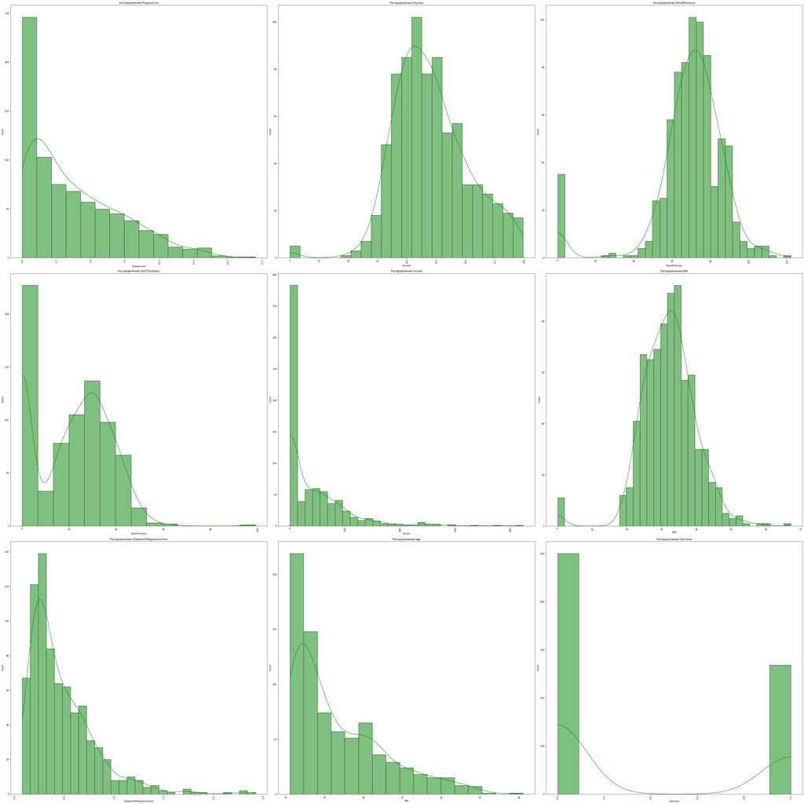

```python
plt.figure(figsize=(50,50))
for index, column in enumerate(df):
    plt.subplot(3,3,index+1)
    plt.title(f"Распределение {column}")
    sns.histplot(data=df, x=column, kde=True, color='g')
    plt.xticks(rotation=90)
plt.tight_layout(pad=1.0)
plt.show()
```

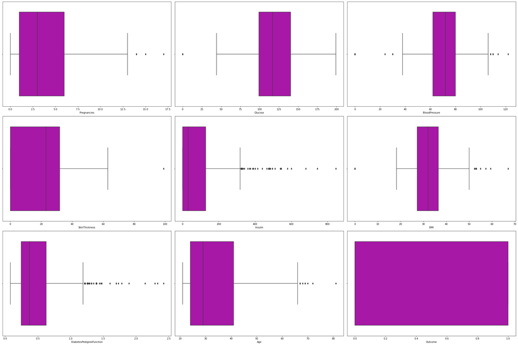

```python
# Ящики с усами для предикторов и зависимой переменной
plt.figure(figsize=(30,20))
for index,column in enumerate(df):
    plt.subplot(3,3,index+1)
    sns.boxplot(data=df, x=column, color='m')

plt.tight_layout(pad=1.0)
```

```python
def del_outliers(data_col, df):
    """
    Функция для удаления выбросов, выходящих за пределы (среднее +- 3*с.к.о.)
    data_col - столбец данных
    df - dataframe
    """
    mean, std = df[data_col].mean(), df[data_col].std()
    cut = std * 3
    lower, upper = mean - cut, mean + cut
    new_df = df[(df[data_col] < upper) & (df[data_col] > lower)]
    return new_df
```

```python
#заменяем нулевые значения на средние или медианные
df['Insulin'] = df.Insulin.replace(0, df.Insulin.median())
df['BloodPressure'] = df.BloodPressure.replace(0,df.BloodPressure.median())
df['BMI'] = df.BMI.replace(0,df.BMI.mean())
```

```python
#преобразуем некоторые столбцы в новые (с удалением выбросов)
df  = del_outliers('Pregnancies',df)
df  = del_outliers('Glucose',df)
df  = del_outliers('BloodPressure',df)
df  = del_outliers('SkinThickness',df)
df  = del_outliers('Insulin',df)
df  = del_outliers('DiabetesPedigreeFunction',df)
df  = del_outliers('Age',df)
```

```python
df.var()
```

```
Pregnancies                   10.752307
Glucose                      880.542935
BloodPressure                128.755970
SkinThickness                244.295195
Insulin                     6002.087464
BMI                           43.542238
DiabetesPedigreeFunction       0.078075
Age                          127.217673
Outcome                        0.223764
dtype: float64
```

```python
#удаляем DPF в связи с очень маленькой дисперсией
df=df.drop('DiabetesPedigreeFunction',axis=1)
```

# 4. Multivariative Data Analysis

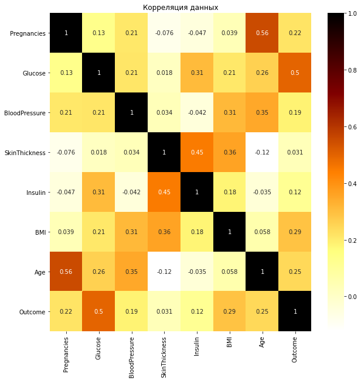

```python
#оценим корреляцию показателей
plt.figure(figsize=(10,10))
plt.title("Корреляция данных")
sns.heatmap(df.corr(), annot=True, cmap=plt.cm.afmhot_r)
plt.show()
```

# Basic Summary

Корреляция выше 0.6 между данными не была замечена (проблемы мультиколлинеарности в данных нет). Значит, данные переменные можно использовать в модели далее.

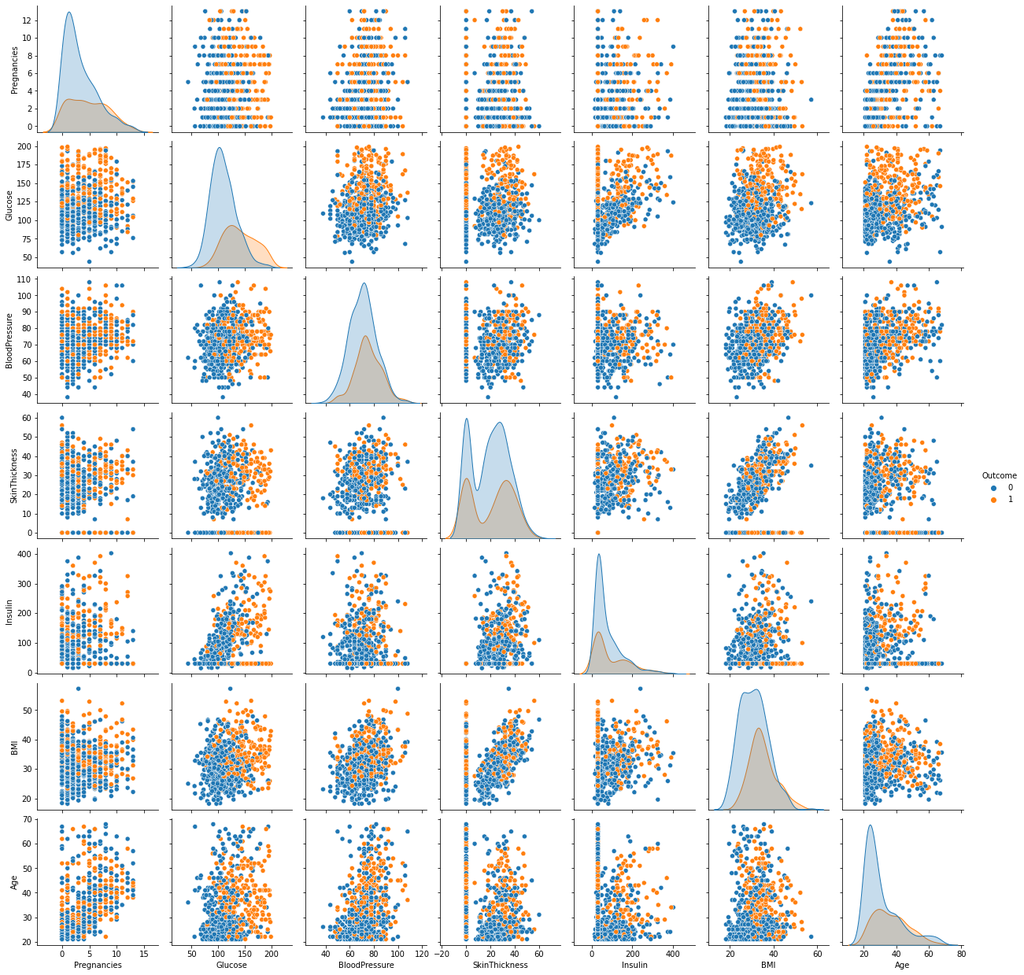

```python
plt.figure(figsize=(15,15))
ax = sns.pairplot(df, hue='Outcome')
plt.show()
```

# Basic Summary

Как видно из графиков выше, переменные Pregnancies, SkinThickness, Insulin, Age имеют распределение, далекое от нормального. В связи с этим, переменные потребуется масштабировать для дальнейшего обучения моделей. Связь между показателями не выглядит линейной.

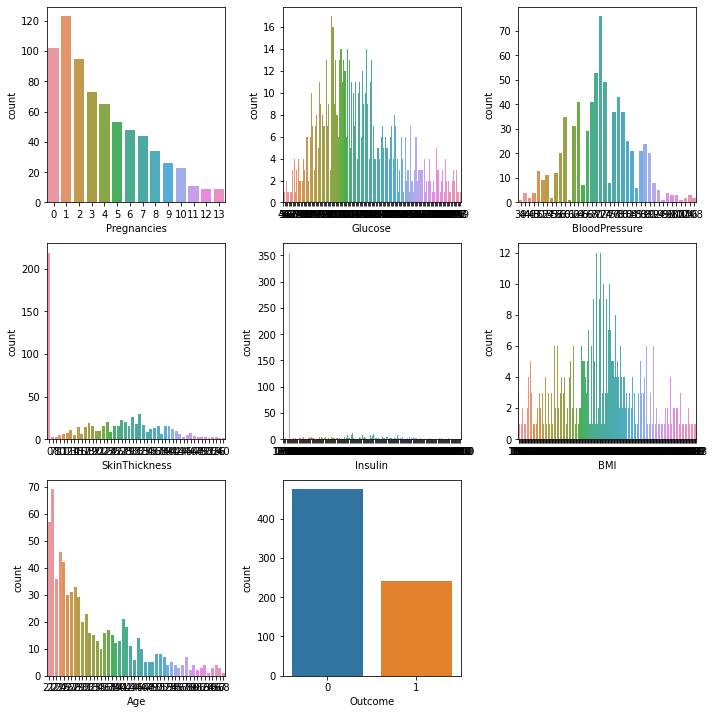

```python
#финальное построение графиков распределения
plt.figure(figsize=(10,10))
for index, column in enumerate(df):
    plt.subplot(3,3,index+1)
    sns.countplot(data=df, x=column)

plt.tight_layout(pad = 1.0)
plt.show()
```

# 5. Data Preprocessing

```python
#формируем зависимые переменные x и независимую переменную Y
X = df.drop('Outcome', axis=1)
y = df['Outcome']
```

```python
col = df.select_dtypes(include=np.number).columns
col
```

```
Index(['Pregnancies', 'Glucose', 'BloodPressure', 'SkinThickness', 'Insulin',
       'BMI', 'Age', 'Outcome'],
      dtype='object')
```

```python
#преобразование через метод StandardScaler
scaler = StandardScaler()
X = scaler.fit_transform(X)
X = pd.DataFrame(X, columns=col[:7])
```

# 6. Models

```python
#Разделение данных на тестовую и тренировочную подвыборки
x_train, x_test, y_train, y_test = train_test_split(X, y, test_size=0.2, random_state=17)
x_train.shape, x_test.shape
```

```
((572, 7), (143, 7))
```

```python
#применение метод "случайные леса"
rd = RandomForestClassifier(random_state=0)
rd.fit(x_train, y_train)
```

```
RandomForestClassifier(random_state=0)
```

```python
#оценивание модели с помощью метрики accuracy
y_pred = rd.predict(x_test)
accuracy_score(y_pred, y_test)
```

```
0.7622377622377622
```

```python
%%time
#расчет наилучших параметров для улучшения качества модели
parameters = {"n_estimators":[10,25,50],
             "criterion": ["gini","entropy"],
             "max_depth": [4, 5],
             "max_features": ["sqrt", "log2"],
             "min_samples_split": [4,7]
             }

rsc = GridSearchCV(estimator=RandomForestClassifier(),
                  param_grid = parameters,
                  cv = 3,
                  verbose=1,
                  scoring='accuracy',
                  n_jobs=1)
rsc.fit(x_train, y_train)

print("Best parameters : ",rsc.best_params_)
print("Best scor {:.3f} ".format(rsc.best_score_))
```

```
Fitting 3 folds for each of 48 candidates, totalling 144 fits
```

```
[Parallel(n_jobs=1)]: Using backend SequentialBackend with 1 concurrent workers.
```

```
Best parameters :  {'criterion': 'gini', 'max_depth': 4, 'max_features': 'sqrt', 'min_samples_split': 4, 'n_estimators': 50}
Best scor 0.780
Wall time: 4.79 s
```

```
[Parallel(n_jobs=1)]: Done 144 out of 144 | elapsed:    4.6s finished
```

```python
#Случайные леса при наилучших параметрах
rd2 = RandomForestClassifier(**rsc.best_params_)
rd2.fit(x_train, y_train)
```

```
RandomForestClassifier(max_depth=4, max_features='sqrt', min_samples_split=4,
                       n_estimators=50)
```

[figure not shown]

```python
#матрица ошибок
cnf_matrix = confusion_matrix(rd2.predict(x_test), y_test)

plt.figure(figsize=(12,12))
p = sns.heatmap(pd.DataFrame(cnf_matrix), annot=True, cmap="YlGnBu" ,fmt='g')
plt.title('Confusion matrix', y=1.1)
plt.ylabel('Actual label')
plt.xlabel('Predicted label')
plt.show()
```

```python
roc_auc_score(y_test,rd2.predict(x_test))
```

```
0.6994884910485932
```

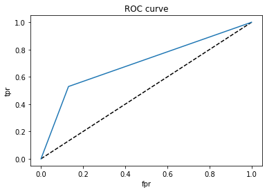

```python
#оценка ROC-AUC-Curve
fpr, tpr, thresholds = roc_curve(y_test, rd2.predict(x_test))

plt.plot([0,1],[0,1],'k--')
plt.plot(fpr,tpr, label='RFC')
plt.xlabel('fpr')
plt.ylabel('tpr')
plt.title('ROC curve')
plt.show()
```

# Conclusion

[figure not shown]

```python
conclusion = {
    "Score": {
    "Baseline Model ": accuracy_score(rd.predict(x_test), y_test)*100,
    "Model after hyperparameter tuning": rsc.best_score_*100
    }
}

ax = pd.DataFrame(conclusion).plot(kind="bar",
                             figsize = (10,5),
                             legend =False,
                             title = "Score",
                             color = 'y');

for p in ax.patches:
    ax.annotate(str(round(p.get_height(), 1)), (p.get_x() * 1.005, p.get_height() * 1.005))
```